# Elements of OAuth 2.0

Stijn Heymans

30 January 2020

# Introduction

Existing OAuth 2.0 protocol explanations are riddled with terminology or tied to specific implementations of the protocol. I’m mainly interested in understanding what problem OAuth 2.0 solves and what the elements of its solution are. In this article, I start with the scenario that you want to give a budgeting tool like mint access to your transaction data at Bank of America. I’ll show the problems with the naive approach and will gradually move toward explaining why OAuth 2.0 solves these problems and how.

I gained my intuition from the book [OAuth 2 in Action](https://www.goodreads.com/book/show/30102872-oauth-2-in-action) which has code-along examples if you want to see the OAuth 2.0 flow at work.

# Login at Bank of America

On Mondays you check your transactions at [Bank of America](https://bankofamerica.com) to see the weekend’s damages. You open up your browser and you navigate to said site. You click *Sign-in* and are presented with the classical login form. Full of anticipation, you enter your username and password and get to see your poor monetary decision making. This is the flow:

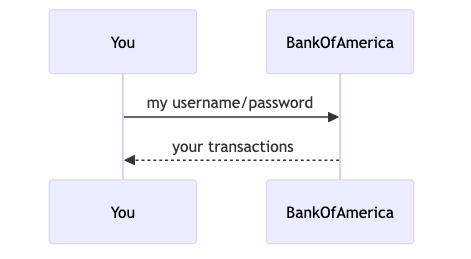

While a sense of dread sets in, we’ll agree that I will refer to your username/password combo as your *credentials*. To add to your existential crisis, I’ll shout at you:

Tip OAuth 2 is not about credentials.

As if things did not start off bad enough, I will also identify you (aka the human) with your browser, and will refer to you and your browser as one (in my defense, at this point in human history, a fair assumption) and officially name you and your browser, the *User*.

I’ll call Bank of America, the *Resource Owner*: they own your transactions (the resources). This how this story looks after dehumanizing it:

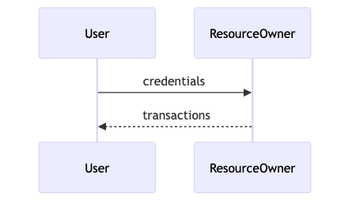

# Use Mint to see your Bank of America Data

As you live in the illusion that life can be better, you want to start using a budgeting tool like mint. mint allows you to pull in your transaction data from a variety of resources. Bank of America may be one of them, as could be your retirement accounts at Vanguard, or your stocks at Morgan Stanley. In this scenario, mint needs access to the *Resource Owner* (Bank of America, Vanguard, …) on behalf of you, the *User*.

The first approach that comes to mind to make this access possible is to let mint ask you for your credentials and pass them straight through to Bank of America whenever mint needs transaction data:

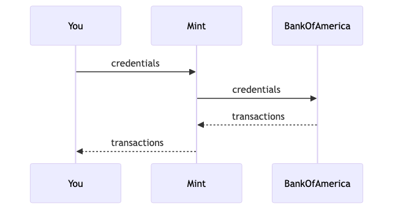

I’ll call mint the *Client* in this scenario, such that the general scheme looks like this:

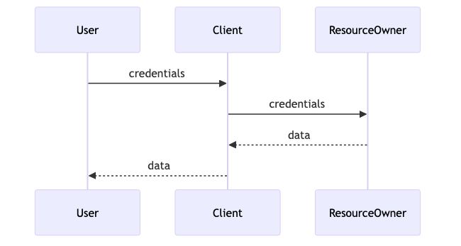

Of course, mint asking you each time for your credentials is unpleasant. So mint might be tempted to think *we’ll ask you once, and then we’ll store it so we don’t have to ask you again*. The flow looks exactly like above, except that now mint asks you for credentials once and then stops asking you as they now store them.

What are the problems with this approach?

- *the client stores your credentials*. If mint gets compromised and your credentials get stolen, someone else now can access your Bank of America account. You have the same problem with Bank of America itself getting compromised, but this scenario increases your risk with a factor of 2 (from 1 place that has your credentials, to 2 places that have your credentials). With each additional client, your risk goes up.
- *anyone with your credentials has the same access you have*. Depending on what you can do as a user, someone having your credentials can do exactly what you can do. Whereas you want mint to *see* your transactions and categorize them, you would not want mint to able to transfer money. However, someone with your credentials from mint could exactly do that.

We’re thus looking for a solution where:

- the client gets read-only access to your transaction data without having to ask you each time for your credentials, aka the client can get the data *on your behalf*
- the client does not store your credentials directly as this is unacceptable risk

# OAuth 2.0

OAuth 2.0, a delegation protocol, solves exactly the above. It’s named a *delegation protocol* as it concerns itself with the *on your behalf* part in the above: how can you, the *User*, delegate *Resource* access to the *Client* without that it exposes you to unacceptable risk? We leave it as an exercise to the reader why the name is *OAuth* and not *ODel*.

## The Players

So far we identified 3 players in the OAuth 2.0 delegation protocol:

- the *User*: you, or a proxy for you, like your browser
- the *Client*: the application you’re interacting with and you want to delegate your access rights to, for example mint
- the *Resource Owner*: the origin of your data, for example Bank of America

OAuth 2.0 introduces a 4th player for the actual authorization:

- the *Authorization Server*.

In our running example, I’ll assume the authorization server is owned by Bank of America, a logical choice as Bank of America is the one that can verify your credentials directly.

## The Dance

Given such an authorization server, can we instruct the client to delegate authorizing you to the authorization server? If yes, the authorization server can then verify your credentials and inform the client that *yes, you can give that user access to the transaction data*.

What are the elements of such a delegation? Let’s see:

- the client (mint) needs to send you, the user (or your browser), to Bank of America’s authorization server
- the authorization server needs to verify your credentials and needs to conclude *yes, you have access*
- the authorization server needs to tell the client that *the particular user has access and can get the data from the Resource Owner*.
- the client needs to take that authorization to the *Resource Owner* to ask for the user’s data

Each of those elements can be accomplished as follows:

- sending the browser to the authorization server can happen using an [HTTP redirect (code 301)](https://moz.com/learn/seo/redirection). The user wants to access the data from the client, but the client instead sends the user’s browser a redirect to the authorization server. The browser subsequently follows that redirect and lands at the authorization server.
- the authorization server then starts an interaction with the user’s browser to get and check the user’s credentials
- the authorization server can tell the client that the user’s credentials are OK by similarly redirecting the user’s browser back to the client by including in the redirect URL something called an *access token*.
- the client would then use that *access token* (which it keeps associated with the user) to go and ask the *Resource Owner* for the user’s data. Since the *Resource Owner* is presumably able to interpret the access token (both the *Resource Owner* as well as the Authorization Server are Bank of America), the *Resource Owner* can verify that the access token is indeed valid.

That flow looks like this:

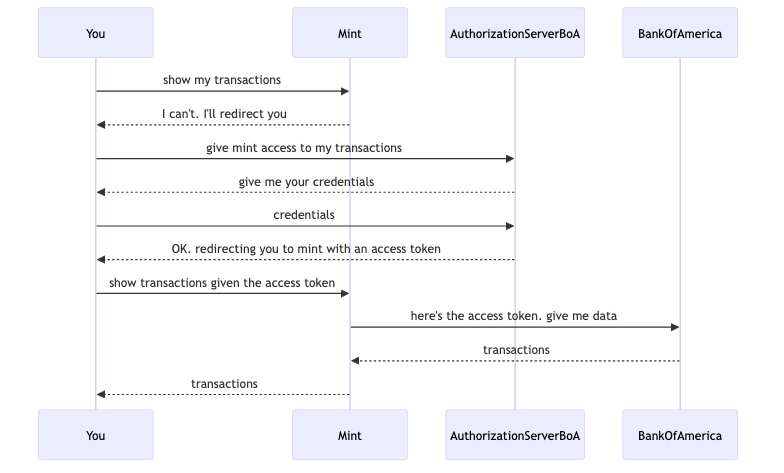

Or abstractly:

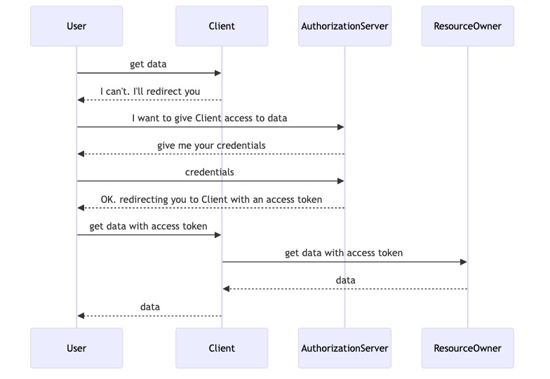

Recall that we had the following problems with the naive approach:

- *the client stores your credentials*
- *anyone with your credentials has the same access you have*

Let’s see whether this new flow solves those problems:

- The client indeed no longer stores your credentials. The client stores the access token, not the credentials. How is that different from storing credentials? The access token has been provided by the authorization server and is assumed to be unique for the client. Thus, when your access token is stolen from the client and used by someone else, the *Resource Owner* can verify that the access token does not belong to the right client. Furthermore, once access tokens are stolen, the *Resource Owner* could disable all access tokens for the client and ask all users to authenticate again. A client being compromised would not affect you, the User, to get data from the *Resource Owner* directly (i.e., by logging into Bank of America directly).
- Someone with the access token does not have the same privileges as you have at the *Resource Owner*. We left that out of the above discussion but clients would redirect you to the authorization server specifically asking for a certain *scope* of access (read-only access to certain parts of your data for example). So even if someone can use your access token, they would be able to do only what the scope for that access token allows them to do (which would presumably not be to transfer money or change your original credentials at Bank of America, but just use your transaction data, which is bad, but not as bad as having the full access you have).

That was not too complicated. However, there is one problem with this access token flow as it is right now. Can you spot it?

Let’s zoom in on the interaction between you, mint, and the Bank of America authorization server:

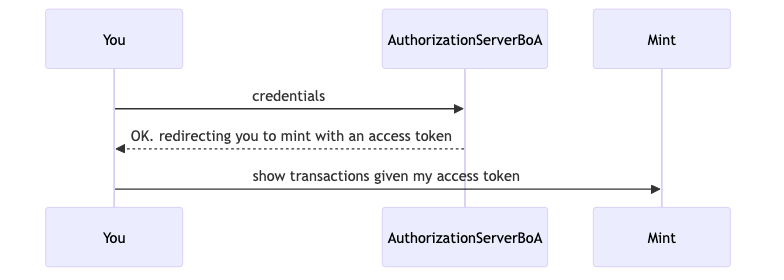

As we explained above, this interaction happens mostly via HTTP redirects over your browser:

- the authorization server sends your browser a redirect with the access token in the URL or body
- the browser hits mint with that access token in the URL where mint stores it and uses it to gain access to the resource (Bank of America)

The problematic part here is the *browser*. This part of the communication, the back-and-forth using redirects, is called the *front-channel* communication and since it goes via your browser it is vulnerable to having the access token intercepted. The *back-channel* communication (for example, from mint to the *Resource Owner*) is much more secure in that respect; there is no user browser involved, just service to service communication.

The way OAuth 2.0 deals with this is to have the Authorization Server not redirect you to the client with the magical access token, but with an authorization code grant instead:

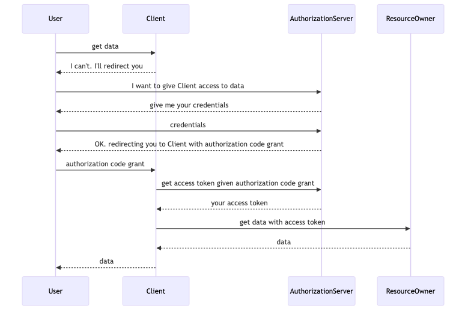

The front-channel no longer sees the access token. It does see the authorization code grant. What if that authorization code grant gets stolen? Can the thief access our data at the *Resource Owner* with that information?

The authorization code grant does not give you access to the data at the *Resource Owner* as the *Resource Owner* needs an access token. Can the thief get an access token from the *Authorization Server* given the authorization code grant?

The getting of the access token happens on the back-channel from the *Client* to the *Authorization Server* and as such can be protected (no *User* involved) by requiring the *Client* to send a *client id* and *client secret* which the *Authorization Server* can verify.

# Conclusion

We illustrated two problems with giving your credentials to a client such as mint directly:

- the client stores your credentials
- someone that steals your credentials has the same access you have

We gradually introduced the OAuth 2.0 flow (*The Dance*) that solves these problems, moving from an incomplete solution with just an access token to a solution with both access token and authorization code grant.

In order to convey the basic intuition (the *why* of OAuth 2.0) we left out many parts such as the different types of authorization code grants, the particular format of access tokens, what refresh tokens are and where they come into play. If you’re interested in learning more check out [OAuth 2 in Action](https://www.goodreads.com/book/show/30102872-oauth-2-in-action) or, better, implement OAuth 2.0 yourself to secure your service.